# Main file TFA reexam (R and VBA part)

Lars Relund Nielsen

# R - Assignment 1 (15%)

Consider the dataset in the file `income.csv` with the monthly income from a population. You can read the dataset file using

```r
library(tidyverse)
dat <- read_csv("income.csv")
head(dat)
```

```
## # A tibble: 6 × 2
##   sex   income
##   <chr>  <dbl>
## 1 male  50336.
## 2 male  39712.
## 3 male  45124.
## 4 male  38807.
## 5 male  44001.
## 6 male  32347.
```

## Question 1

Fit probability distributions to data for both men and women.

Guiding solution:

The data are continuous and we try to fit a continuous distribution.

**Male:**

Guiding solution:

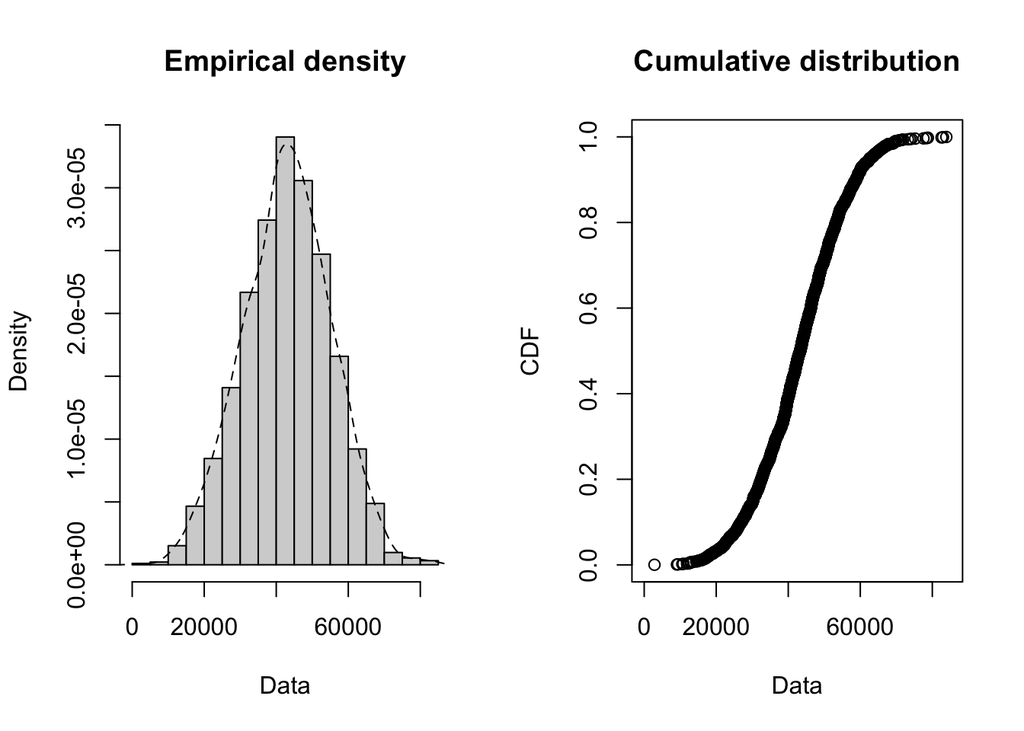

```r
library(fitdistrplus)
datM <- dat %>%
   filter(sex == "male") %>%
   pull(income)
plotdist(datM, histo = TRUE, demp = TRUE)
```

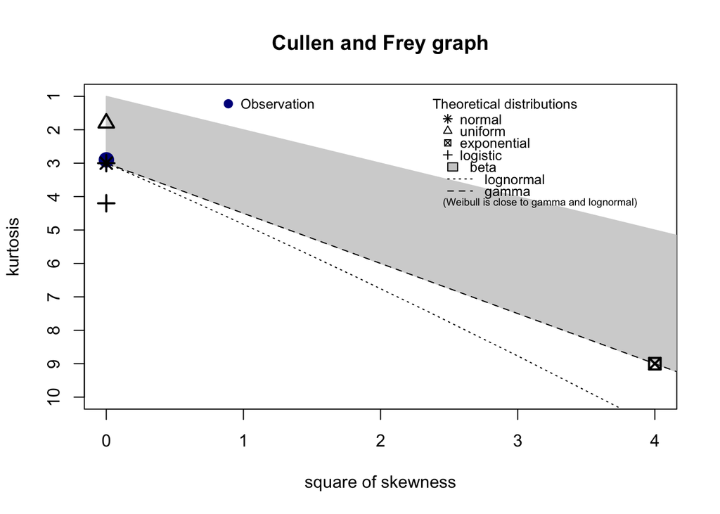

```
## summary statistics
## ------
## min:  2855.833   max:  83894.58
## median:  43290.91
## mean:  43047.59
## estimated sd:  12175.8
## estimated skewness:  -0.02762095
## estimated kurtosis:  2.900475
```

```r
descdist(datM)
```

A normal distribution seem as a good choice.

Guiding solution:

```r
fitM <- fitdist(datM, distr = "norm")
summary(fitM)
```

```
## Fitting of the distribution ' norm ' by maximum likelihood
## Parameters :
##      estimate Std. Error
## mean 43047.59   280.2437
## sd   12172.50   205.6427
## Loglikelihood:  -19973.74   AIC:  39951.47   BIC:  39962.51
## Correlation matrix:
##      mean sd
## mean    1  0
## sd      0  1
```

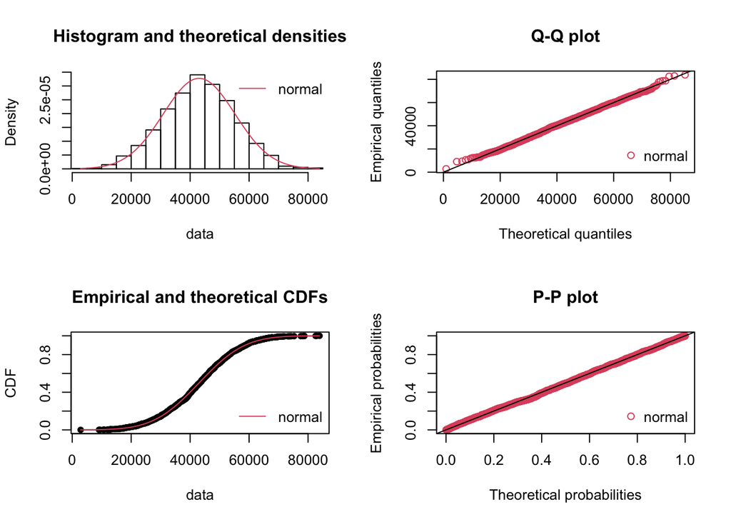

```r
par(mfrow = c(2, 2))  # 4 plots in one figure
pLegend <- c("normal")
lst <- list(fitM)
denscomp(lst, legendtext = pLegend)
qqcomp(lst, legendtext = pLegend)
cdfcomp(lst, legendtext = pLegend)
ppcomp(lst, legendtext = pLegend)
```

A normal distribution seem to fit very well.

**Female**:

Guiding solution:

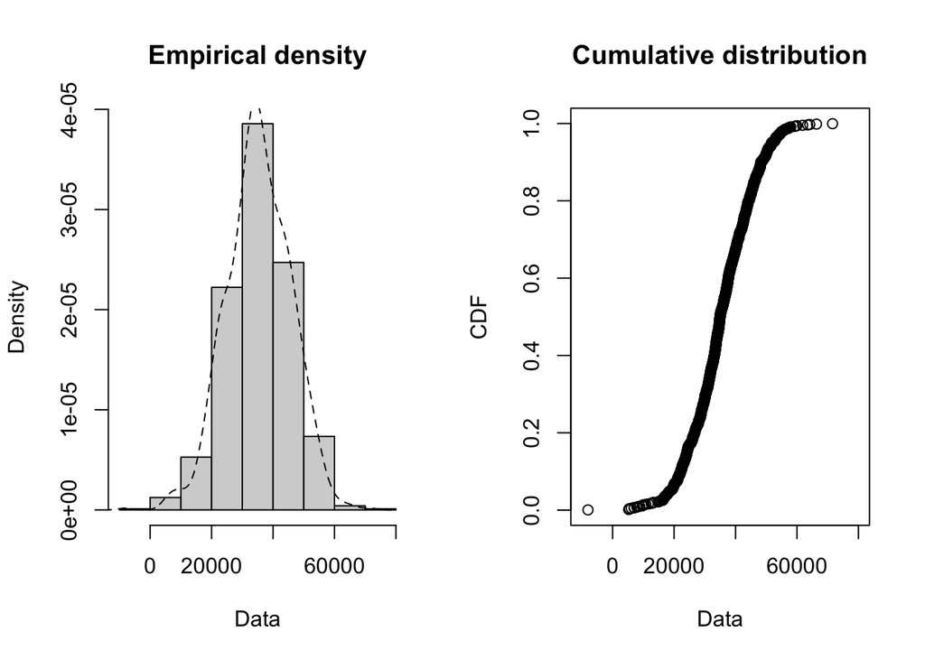

```r
datF <- dat %>%
   filter(sex == "female") %>%
   pull(income)
plotdist(datF, histo = TRUE, demp = TRUE)
```

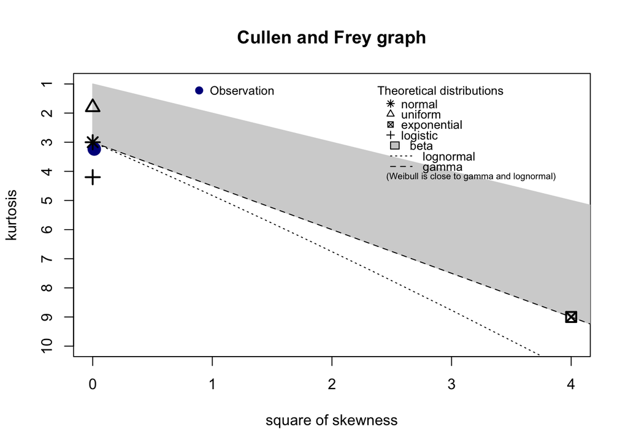

```
## summary statistics
## ------
## min:  -8021.926   max:  71567.97
## median:  34953.92
## mean:  35340.26
## estimated sd:  10336.34
## estimated skewness:  -0.1151169
## estimated kurtosis:  3.234149
```

```r
descdist(datF)
```

A normal distribution seem as a good choice.

Guiding solution:

```r
fitF <- fitdist(datF, distr = "norm")
summary(fitF)
```

```
## Fitting of the distribution ' norm ' by maximum likelihood
## Parameters :
##      estimate Std. Error
## mean 35340.26   331.5888
## sd   10330.99   234.4687
## Loglikelihood:  -10310   AIC:  20624   BIC:  20633.75
## Correlation matrix:
##      mean sd
## mean    1  0
## sd      0  1
```

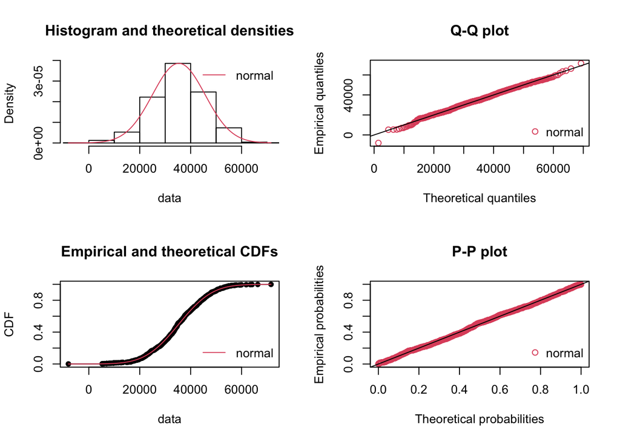

```r
par(mfrow = c(2, 2))  # 4 plots in one figure
pLegend <- c("normal")
lst <- list(fitF)
denscomp(lst, legendtext = pLegend)
qqcomp(lst, legendtext = pLegend)
cdfcomp(lst, legendtext = pLegend)
ppcomp(lst, legendtext = pLegend)
```

A normal distribution seem to fit very well.

## Question 2

Make a plot using `ggplot` of the two empirical densities with the following features:

- Different fill colours are used for each sex.
- Informative figure title and axis titles are given.

Based on the plot and Question 1, is there any difference in the income for men and women? If yes on average how much?

Guiding solution:

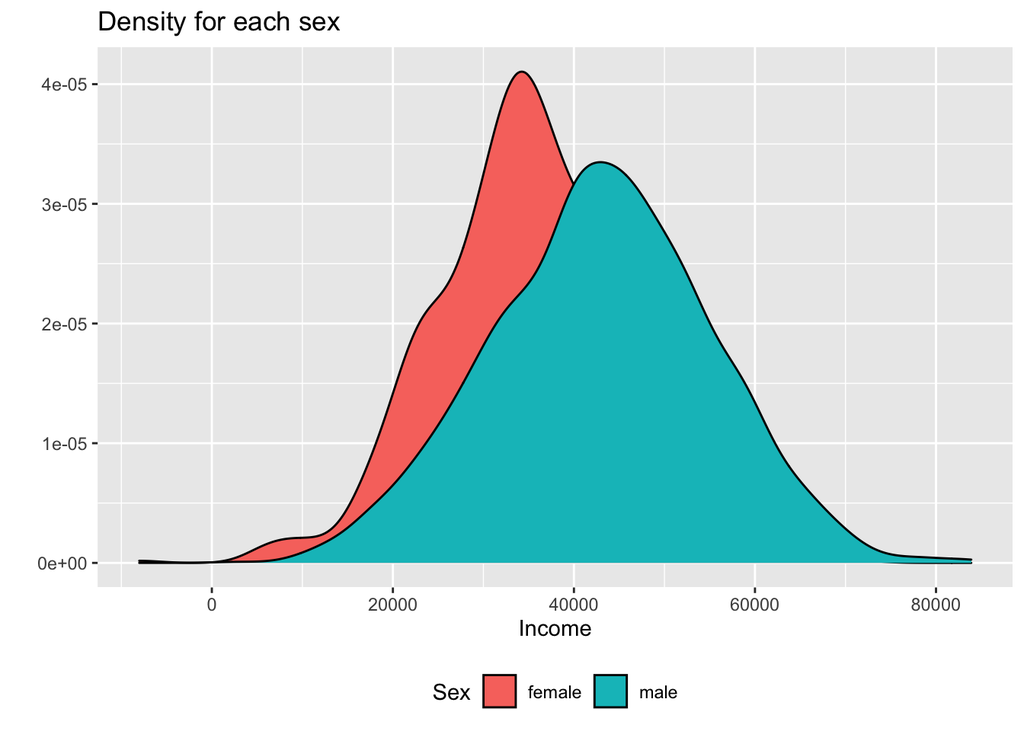

```r
dat %>%
   ggplot(aes(x = income, fill = sex)) +
   geom_density() +
   labs(title = "Density for each sex",
       x = "Income",
       y = "",
       fill = "Sex"
    ) +
   theme(legend.position = "bottom")
```

Based on the plot there seems to be a difference in income for men and women. We may use the mean values estimated to find the average difference:

Guiding solution:

```r
fitM$estimate[1] - fitF$estimate[1]
```

```
##     mean
## 7707.333
```

# R - Assignment 2 (18%)

Consider COVID-19 data obtained from Our World in Data in the file `covid.csv`. The dataset contains data from different countries. Some of the columns/variables are:

- `cases`: New confirmed cases of COVID-19.
- `deaths`: New deaths attributed to COVID-19.
- `icu_patients`: Number of COVID-19 patients in intensive care units (ICUs) on a given day.
- `hosp_patients`: Number of COVID-19 patients in hospital on a given day.
- `tests`: Total tests for COVID-19.
- `positive_rate`: The share of COVID-19 tests that are positive, given as a rolling 7-day average.
- `vac`: Total number of people who received at least one vaccine dose.
- `fully_vac`: Total number of people who received all doses prescribed by the vaccination protocol.
- `population`: Country population.

Other columns are `date`, `country`, `month` and `year`. You can read the dataset file using

```r
library(tidyverse)
dat <- read_csv("covid.csv")
```

Use the *dplyr* package in *tidyverse* to calculate relevant summary tables (tibbles/data frames) and answer the following questions.

## Question 1

Which countries are considered and what is the timespan of the data?

Guiding solution:

```r
res1 <- dat %>%
   distinct(country) %>%
  print()
```

```
## # A tibble: 4 × 1
##   country
##   <chr>
## 1 Denmark
## 2 Germany
## 3 Norway
## 4 United Kingdom
```

```r
res2 <- dat %>%
   ungroup() %>%
   summarise(start = min(date), end = max(date)) %>%
   print()
```

```
## # A tibble: 1 × 2
##   start      end
##   <date>     <date>
## 1 2020-01-27 2021-11-24
```

We have a total of 4 countries with data from 2020-01-27 to 2021-11-24.

## Question 2

What is the number of new confirmed cases November 22nd, 2021 in Denmark?

Guiding solution:

```r
res <- dat %>%
   filter(country == "Denmark", date == "2021-11-22") %>%
  print()
```

```
## # A tibble: 1 × 13
##   date       country cases deaths icu_patients hosp_patients tests positive_rate     vac
##   <date>     <chr>   <dbl>  <dbl>        <dbl>         <dbl> <dbl>         <dbl>   <dbl>
## 1 2021-11-22 Denmark  3810      6           NA            NA    NA            NA 4544857
## # … with 4 more variables: fully_vac <dbl>, population <dbl>, month <dbl>, year <dbl>
```

The number of confirmed cases was 3810.

## Question 3

Calculate the total number of confirmed cases and deaths. Hint: you may use the `cumsum` function to add all cases up until a given date. You may here consider `NA` values in the `cases` and `deaths` columns as equal to zero (e.g. using `replace_na(cases, 0)`).

What is the total number of deaths in Norway up to October 10th, 2021?

Guiding solution:

```r
res1 <- dat %>%
   group_by(country) %>%
   mutate(total_cases = cumsum(replace_na(cases, 0)),
          total_deaths = cumsum(replace_na(deaths, 0))) %>%
   print()
```

```
## # A tibble: 2,628 × 15
## # Groups:   country [4]
##    date       country cases deaths icu_patients hosp_patients tests positive_rate   vac
##    <date>     <chr>   <dbl>  <dbl>        <dbl>         <dbl> <dbl>         <dbl> <dbl>
##  1 2020-02-02 Denmark    NA     NA           NA            NA     1            NA    NA
##  2 2020-02-03 Denmark    NA     NA           NA            NA    NA            NA    NA
##  3 2020-02-04 Denmark    NA     NA           NA            NA    NA            NA    NA
##  4 2020-02-05 Denmark    NA     NA           NA            NA    NA            NA    NA
##  5 2020-02-06 Denmark    NA     NA           NA            NA    NA            NA    NA
##  6 2020-02-07 Denmark    NA     NA           NA            NA    NA            NA    NA
##  7 2020-02-08 Denmark    NA     NA           NA            NA    NA            NA    NA
##  8 2020-02-09 Denmark    NA     NA           NA            NA    NA            NA    NA
##  9 2020-02-10 Denmark    NA     NA           NA            NA    NA            NA    NA
## 10 2020-02-11 Denmark    NA     NA           NA            NA    NA            NA    NA
## # … with 2,618 more rows, and 6 more variables: fully_vac <dbl>, population <dbl>,
## #   month <dbl>, year <dbl>, total_cases <dbl>, total_deaths <dbl>
```

```r
res2 <- res1 %>%
   filter(country == "Norway", date == "2021-10-10") %>%
   select(contains("total")) %>%
   print()
```

```
## # A tibble: 1 × 3
## # Groups:   country [1]
##   country total_cases total_deaths
##   <chr>         <dbl>        <dbl>
## 1 Norway       193562          871
```

The total number of deaths in Norway up to 10th October 2021 is 871.

## Question 4

For each country calculate the number of tests done in each month in a given year. Which country had the highest number of tests per capita in March 2021?

Guiding solution:

```r
res1 <- dat %>%
   group_by(country, month, year, population) %>%
   summarize(tests = max(tests, na.rm = TRUE) - min(tests, na.rm = TRUE)) %>%
   ungroup() %>%
   mutate(testsCap = tests/population) %>%
   arrange(desc(year), month) %>%
   print()
```

```
## # A tibble: 90 × 6
##    country        month  year population    tests testsCap
##    <chr>          <dbl> <dbl>      <dbl>    <dbl>    <dbl>
##  1 Denmark            1  2021    5813302  2863482   0.493
##  2 Germany            1  2021   83900471  4684292   0.0558
##  3 Norway             1  2021    5465629   581599   0.106
##  4 United Kingdom     1  2021   68207114 16382170   0.240
##  5 Denmark            2  2021    5813302  3357579   0.578
##  6 Germany            2  2021   83900471  3335631   0.0398
##  7 Norway             2  2021    5465629   429646   0.0786
##  8 United Kingdom     2  2021   68207114 15305191   0.224
##  9 Denmark            3  2021    5813302  4881781   0.840
## 10 Germany            3  2021   83900471  4068985   0.0485
## # … with 80 more rows
```

```r
res2 <- res1 %>%
   filter(year == 2021, month == 3) %>%
   arrange(desc(testsCap)) %>%
   print()
```

```
## # A tibble: 4 × 6
##   country        month  year population    tests testsCap
##   <chr>          <dbl> <dbl>      <dbl>    <dbl>    <dbl>
## 1 Denmark            3  2021    5813302  4881781   0.840
## 2 United Kingdom     3  2021   68207114 33279694   0.488
## 3 Norway             3  2021    5465629   791345   0.145
## 4 Germany            3  2021   83900471  4068985   0.0485
```

The highest number of tests per capita in March 2021 was in Denmark.

## Question 5

Consider United Kingdom. Which month had the highest number of ICU patients on a given day?

Guiding solution:

```r
res <- dat %>%
   filter(country == "United Kingdom") %>%
   group_by(country, year, month) %>%
   summarize(icu = max(icu_patients, na.rm = TRUE)) %>%
   arrange(desc(icu)) %>%
   print()
```

```
## # A tibble: 23 × 4
## # Groups:   country, year [2]
##    country         year month   icu
##    <chr>          <dbl> <dbl> <dbl>
##  1 United Kingdom  2021     1  4077
##  2 United Kingdom  2021     2  3726
##  3 United Kingdom  2020     4  3301
##  4 United Kingdom  2020     5  2178
##  5 United Kingdom  2020    12  2122
##  6 United Kingdom  2021     3  1806
##  7 United Kingdom  2020    11  1489
##  8 United Kingdom  2021     9  1081
##  9 United Kingdom  2021    11  1034
## 10 United Kingdom  2021     8  1014
## # … with 13 more rows
```

The highest number of ICU patients on a given day was in January (4077 patients).

# R - Assignment 3 (17%)

Answer this assignment using the *ggplot2* package in *tidyverse* (you may need *dplyr* for preparing the datasets you want to plot). We work with the dataset from Assignment 2 which can be read using:

```r
library(tidyverse)
dat <- read_csv("covid.csv")
```

## Question 1

Create a visualization showing the number of cases for each date in Denmark with the following features:

- A blue line is used to visualize the data.
- Informative figure title and axis titles are given.

Is the number of cases low or high in July 2020 in the plot?

Guiding solution:

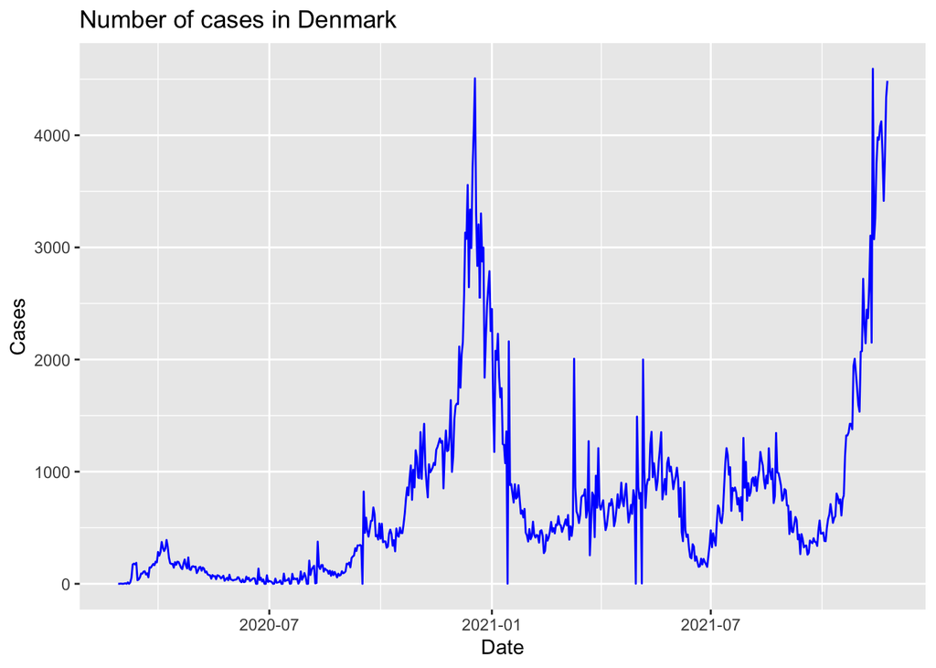

```r
dat %>%
   filter(country == "Denmark", !is.na(cases)) %>%
   ggplot(aes(y = cases, x = date)) +
   geom_line(color = "blue") +
   labs(title = "Number of cases in Denmark",
       x = "Date",
       y = "Cases"
    )
```

The number of cases in July 2020 are low.

## Question 2

Create a visualization showing the total number of deaths per 100000 capita as a function of date with the following features:

- Different colours are used for each country.
- Lines are used to visualize the data.
- Legends are put at the bottom of the plot.
- Informative figure title and axis titles are given.

Hint: you may use the `cumsum` function to add all deaths up until a given date. You may here consider `NA` values in the `deaths` column as equal to zero (e.g. using `replace_na(deaths, 0)`).

Which country has the highest relative number of deaths in general?

Guiding solution:

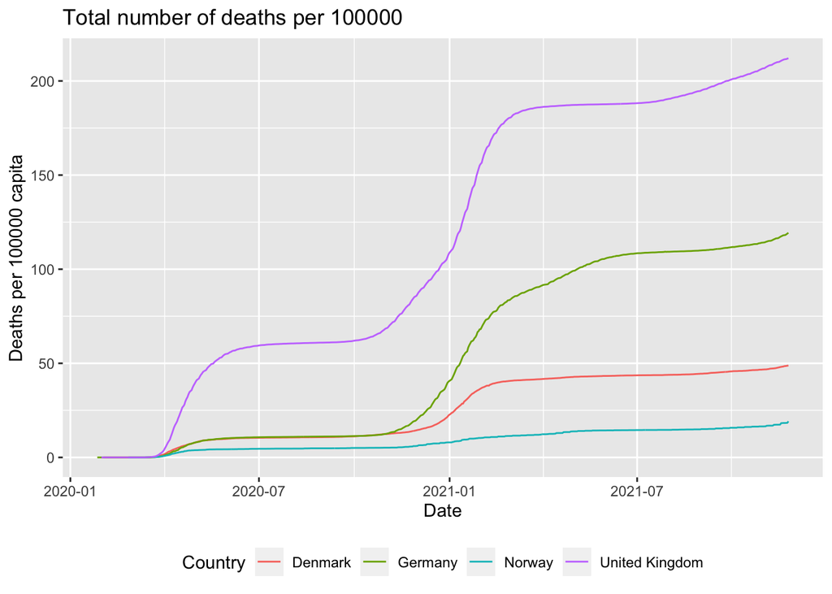

```r
dat %>%
   group_by(country) %>%
   mutate(total_deaths = cumsum(replace_na(deaths, 0))) %>%
   mutate(total_deaths_cap = total_deaths/(population/100000)) %>%
   ggplot(aes(x = date, y = total_deaths_cap, color = country)) +
   geom_line() +
   labs(title = "Total number of deaths per 100000",
       x = "Date",
       y = "Deaths per 100000 capita",
       color = "Country"
    ) +
   theme(legend.position = "bottom")
```

The highest relative number of deaths are for the United Kingdom.

## Question 3

Create a visualization showing the percentage of persons vaccinated as a function of date with the following features:

- We consider 2021.
- Different colours are used to differ between vaccinated and fully vaccinated.
- The plot is divided using `country` (facet).
- Lines are used to visualize the data.
- Informative figure title and axis titles are given.

Hint: If you calculated the two percentages in two new columns `partly` and `full`, then the values can be joined to one column using

```r
dat %>%
   pivot_longer(cols = c(partly, full))
```

Which country has the highest percentage of vaccinated people and the lowest gap between partly and fully vaccinated?

Guiding solution:

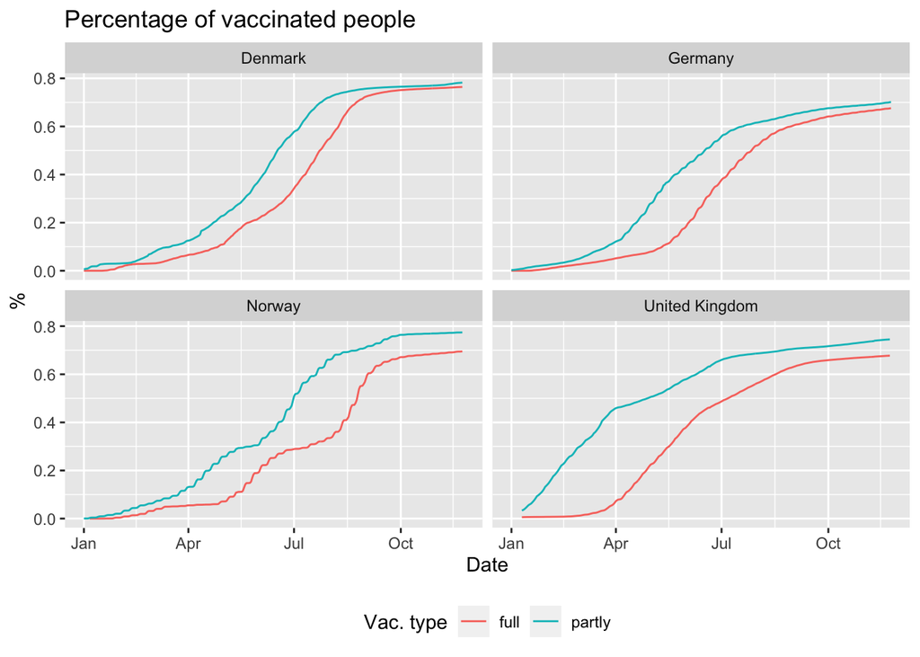

```r
dat %>%
   filter(year == 2021) %>%
   mutate(partly = vac/population,
          full = fully_vac/population) %>%
   pivot_longer(cols = c(partly, full)) %>%
   ggplot() +
   geom_line(aes(x = date, y = value, color = name)) +
   facet_wrap(vars(country)) +
   labs(title = "Percentage of vaccinated people",
       x = "Date",
       y = "%",
       color = "Vac. type") +
   theme(legend.position = "bottom")
```

The plot showes that Denmark has the highest percentage of vaccinated people and the lowest gap between partly and full vaccinated.

## Question 4

Consider Germany. Create a visualization showing the variation in ICU patients with the following features:

- A sub-plot is given for each month and year (facet).
- Informative figure title and axis titles are given.

In which year did the ICU have the most patients when considering October?

Guiding solution:

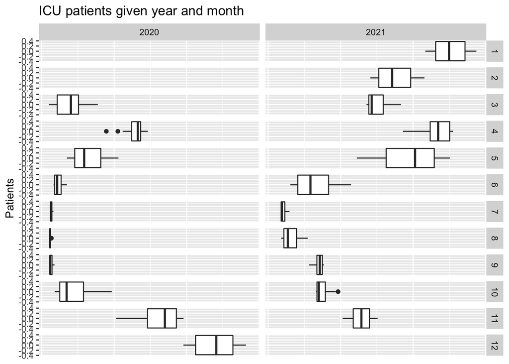

```r
dat %>%
   filter(country == "Germany") %>%
  ggplot(aes(x = icu_patients)) +
  geom_boxplot() +
  facet_grid(month ~ year, scales = "free_y") +
  labs(title = "ICU patients given year and month",
       x = "",
       y = "Patients") +
  theme(axis.title.x=element_blank(),
        axis.text.x=element_blank(),
        axis.ticks.x=element_blank(),
        legend.position = "bottom")
```

In 2021 the mean value of the ICU patients was highest when considering October.

## Question 5

Create a visualization showing the total number of deaths per 100000 capita for each country and year with the following features:

- The numbers are shown using columns for each country
- Different fill colours are used for year. Hint: columns for each year can be shown beside each other using `position = position_dodge()`.
- Informative figure title and axis titles are given.

Which country had the lowest number of deaths in 2021?

Guiding solution:

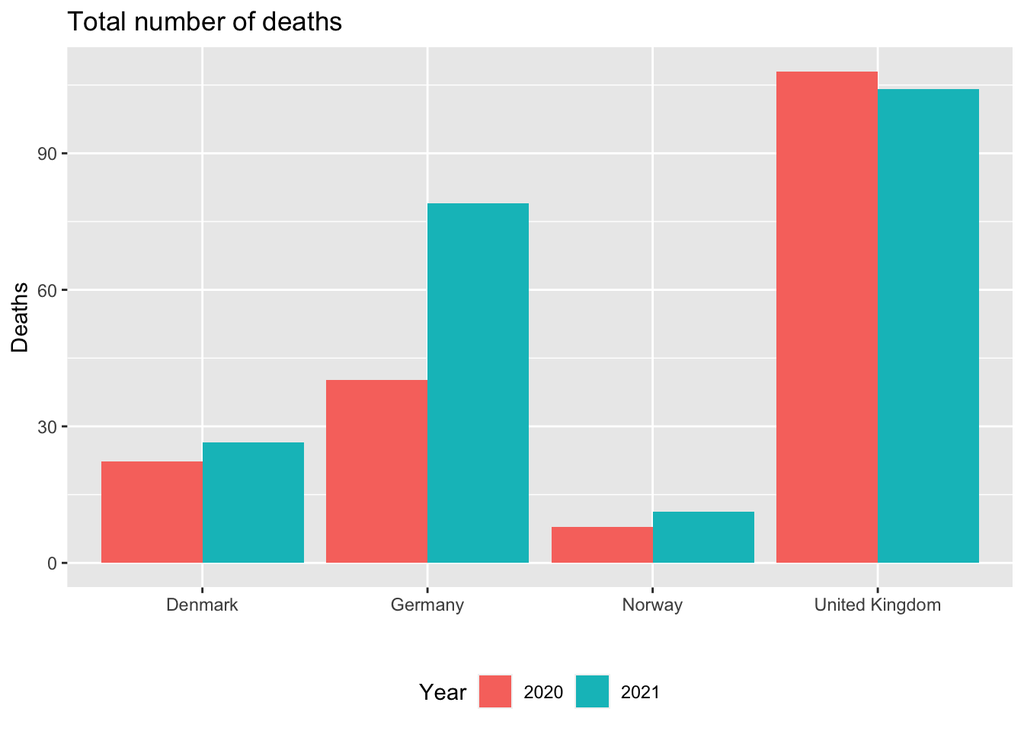

```r
dat %>%
   group_by(country, year) %>%
   summarise(deaths = sum(deaths/(population/100000) , na.rm = TRUE)) %>%
   ggplot(aes(y = deaths, x = country, fill = factor(year))) +
   geom_col(position = position_dodge()) +
   labs(title = "Total number of deaths",
    x = "",
    y = "Deaths",
    fill = "Year") +
   theme(legend.position = "bottom")
```

Norway had the lowest number of deaths in 2021.